# Basic Statistical Tests in R

This RMarkdown document illustrates how to do most basic statistical tests in R. Remember that the code blocks contain R code and can be executed by clicking the triangular “play” button in the corner. Everything outside of the code blocks can be used for keeping notes. Headings are preceded by hash tags.

You can insert new code blocks by clicking on “Insert” icon on the top of the Source pane. Alternatively, you can just type the beginning and ending delimiters (three grave accents, with {r} at the beginning).

```r
2+2
```

```
## [1] 4
```

## Why R?

- Reproducibility (for you and for others)
- Powerful
- Very deep community of support
- Free (*gratis*)
- Free (*libre*)

## Overview

- RMarkdown workflow
- Vectors
- Data frames
- Some basic statistical tests

## Vectors

- Often you want to deal with several numbers at once.
- The `c( )` operator *combines* its contents into a *vector*.

```r
c(2,4,6,2,10)
```

```
## [1]  2  4  6  2 10
```

```r
c(2,4,6,2,10) + c(10, 20, 30, 40, 50)
```

```
## [1] 12 24 36 42 60
```

```r
c(2,4,6,2,10) * 1000
```

```
## [1]  2000  4000  6000  2000 10000
```

## Variables

- Often you want to save a vector so you can reuse it.
- The assignment operator `<-` saves a variable.
- Notice that after you execute the following code block, the value of the variable `joe` appears in the Environment tab in the upper-right pane of RStudio.

```r
joe <- c(2,4,6,2,10)
joe^2
```

```
## [1]   4  16  36   4 100
```

```r
sum(joe)
```

```
## [1] 24
```

```r
mean(joe)
```

```
## [1] 4.8
```

## Data Frames in R

- The basic form of data. Think spreadsheet.
- Columns have the same length, but can be different types.
- One row per observational unit.

## Built-in data sets: `iris`

The following code block loads a built-in data set called `iris` and prints a summary of its columns. When you execute this code block, you should see the name `iris` appear in the Environment tab in the upper-right pane of RStudio. If you click on the name of a data frame in the Environment tab, a spreadsheet view of the data frame will appear in the Source pane. This view is non-editable (which is a good thing).

```r
data("iris")
summary(iris)
```

```
##   Sepal.Length    Sepal.Width     Petal.Length    Petal.Width
##  Min.   :4.300   Min.   :2.000   Min.   :1.000   Min.   :0.100
##  1st Qu.:5.100   1st Qu.:2.800   1st Qu.:1.600   1st Qu.:0.300
##  Median :5.800   Median :3.000   Median :4.350   Median :1.300
##  Mean   :5.843   Mean   :3.057   Mean   :3.758   Mean   :1.199
##  3rd Qu.:6.400   3rd Qu.:3.300   3rd Qu.:5.100   3rd Qu.:1.800
##  Max.   :7.900   Max.   :4.400   Max.   :6.900   Max.   :2.500
##        Species
##  setosa    :50
##  versicolor:50
##  virginica :50
##
##
##
```

## Columns are vectors

Use the `$` operator to return the columns of a data frame.

```r
iris$Sepal.Length
```

```
##   [1] 5.1 4.9 4.7 4.6 5.0 5.4 4.6 5.0 4.4 4.9 5.4 4.8 4.8 4.3 5.8 5.7 5.4 5.1
##  [19] 5.7 5.1 5.4 5.1 4.6 5.1 4.8 5.0 5.0 5.2 5.2 4.7 4.8 5.4 5.2 5.5 4.9 5.0
##  [37] 5.5 4.9 4.4 5.1 5.0 4.5 4.4 5.0 5.1 4.8 5.1 4.6 5.3 5.0 7.0 6.4 6.9 5.5
##  [55] 6.5 5.7 6.3 4.9 6.6 5.2 5.0 5.9 6.0 6.1 5.6 6.7 5.6 5.8 6.2 5.6 5.9 6.1
##  [73] 6.3 6.1 6.4 6.6 6.8 6.7 6.0 5.7 5.5 5.5 5.8 6.0 5.4 6.0 6.7 6.3 5.6 5.5
##  [91] 5.5 6.1 5.8 5.0 5.6 5.7 5.7 6.2 5.1 5.7 6.3 5.8 7.1 6.3 6.5 7.6 4.9 7.3
## [109] 6.7 7.2 6.5 6.4 6.8 5.7 5.8 6.4 6.5 7.7 7.7 6.0 6.9 5.6 7.7 6.3 6.7 7.2
## [127] 6.2 6.1 6.4 7.2 7.4 7.9 6.4 6.3 6.1 7.7 6.3 6.4 6.0 6.9 6.7 6.9 5.8 6.8
## [145] 6.7 6.7 6.3 6.5 6.2 5.9
```

You can calculate descriptive statistics on each column.

```r
mean(iris$Sepal.Length)
```

```
## [1] 5.843333
```

```r
sd(iris$Petal.Width)
```

```
## [1] 0.7622377
```

# MA-5 in 5 Minutes

## Basic Statistical Tests in R

- Once the data is loaded, most tests are one line of code.
- Simple graphs are also one-liners (base graphics).

## MA-5 Topics I cover

- One proportion and one mean
- Two proportions and two means (independent samples and paired)
- Multiple proportions ($\chi^2$)
- Multiple means (ANOVA)
- Regression and Correlation
- Multiple linear regression
- MANOVA, Factorial ANOVA, Logistic Regression (optional)
- Nonparametric resampling techniques for most of these

# One Sample Tests

## One-Proportion Test

If Steve gets 54 out of 83 correct on a True/False test, is this evidence that he is doing something other than just guessing randomly?

```r
prop.test(54, 83, p = 0.5)
```

```
##
##  1-sample proportions test with continuity correction
##
## data:  54 out of 83, null probability 0.5
## X-squared = 6.9398, df = 1, p-value = 0.00843
## alternative hypothesis: true p is not equal to 0.5
## 95 percent confidence interval:
##  0.5373112 0.7498063
## sample estimates:
##         p
## 0.6506024
```

## One-Sample $t$-test

I asked my statistics students to report how many hours of sleep they got last night. The data is posted on our website, and the following line will load it and summarize it.

```r
sleep <- read.table("http://math.westmont.edu/ma5/classSleep.txt", header = TRUE)
summary(sleep)
```

```
##    SleepHours
##  Min.   : 3.000
##  1st Qu.: 7.000
##  Median : 7.500
##  Mean   : 7.404
##  3rd Qu.: 8.000
##  Max.   :11.000
```

## One-Sample $t$-test

By default, a one-sample t-test uses a null value of zero and a two-sided alternative.

```r
t.test(sleep)
```

```
##
##  One Sample t-test
##
## data:  sleep
## t = 48.81, df = 84, p-value < 2.2e-16
## alternative hypothesis: true mean is not equal to 0
## 95 percent confidence interval:
##  7.102688 7.706018
## sample estimates:
## mean of x
##  7.404353
```

## $t$-test help menu

Typing a question mark before the name of a command will bring up the help page for the command in the lower-right pane of RStudio.

```r
?t.test
```

## One-sided $t$-test

In the description of the command in the help page, the equals signs show the default values. You can change these to customize the command.

Does my class sample provide evidence that college students get less than 8 hours of sleep?

```r
t.test(sleep, alternative="less", mu=8)
```

```
##
##  One Sample t-test
##
## data:  sleep
## t = -3.9266, df = 84, p-value = 8.795e-05
## alternative hypothesis: true mean is less than 8
## 95 percent confidence interval:
##      -Inf 7.656654
## sample estimates:
## mean of x
##  7.404353
```

## Other confidence levels

Based on my sample, what are plausible values of the average number of hours of sleep that college students get, with 99% confidence?

```r
t.test(sleep, conf.level=0.99)
```

```
##
##  One Sample t-test
##
## data:  sleep
## t = 48.81, df = 84, p-value < 2.2e-16
## alternative hypothesis: true mean is not equal to 0
## 99 percent confidence interval:
##  7.004537 7.804169
## sample estimates:
## mean of x
##  7.404353
```

# Explanatory/Response Scenarios

## Explanatory/Response variables

| Explanatory | Response | Scenario/Test |
| --- | --- | --- |
| Categorical (2 levels) | Categorical | two-proportion $z$-test |
| Categorical (2 levels, independent) | Quantitative | two-sample $t$-test |
| Categorical (2 levels, paired) | Quantitative | paired $t$-test |
| Categorical (>2 levels) | Categorical | $\chi^2$ test |
| Categorical (>2 levels) | Quantitative | ANOVA $F$-test |
| Quantitative | Quantitative | Regression/Correlation |

## Formulas in R

- Explanatory (x) and response (y) variables are usually denoted using “tilde” notation: `y ~ x`
- The tilde means “as explained by” or “as a function of”.
- Works in different contexts (tests, plots)
- Can also have multiple response, explanatory variables (e.g., multiple regression, ANCOVA)

## Two-sample $t$-test

```r
friends <- read.table("http://www.isi-stats.com/isi/data/chap6/CloseFriends.txt",
                      header = TRUE,
                      stringsAsFactors = TRUE)
summary(friends)
```

```
##     Sex         Friends
##  Men  :654   Min.   :0.000
##  Women:813   1st Qu.:0.000
##              Median :2.000
##              Mean   :1.987
##              3rd Qu.:3.000
##              Max.   :6.000
```

## Plot using formula

- Explanatory: Sex (Male or Female)
- Response: How many close friends do you have?

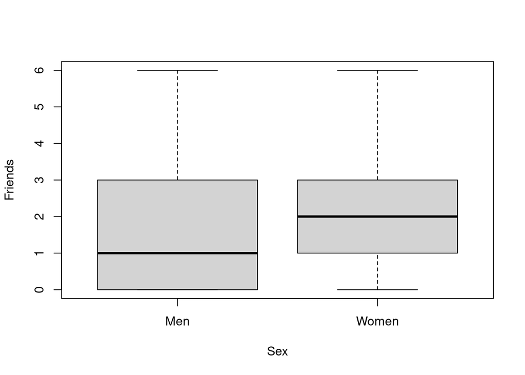

```r
plot(Friends ~ Sex, data = friends)
```

## Two-sample $t$-test using formula

Do men and women differ on how many close friends they say they have?

```r
t.test(Friends ~ Sex, data = friends)
```

```
##
##  Welch Two Sample t-test
##
## data:  Friends by Sex
## t = -2.4497, df = 1392.8, p-value = 0.01442
## alternative hypothesis: true difference in means is not equal to 0
## 95 percent confidence interval:
##  -0.41004255 -0.04536669
## sample estimates:
##   mean in group Men mean in group Women
##            1.860856            2.088561
```

## Paired $t$-test

Is it faster to take a wide angle or a narrow angle when rounding first base to get to second?

```r
rounding1st <- read.table("http://www.isi-stats.com/isi/data/chap7/FirstBase.txt", header=TRUE)
summary(rounding1st)
```

```
##      narrow           wide
##  Min.   :5.000   Min.   :4.950
##  1st Qu.:5.463   1st Qu.:5.350
##  Median :5.525   Median :5.450
##  Mean   :5.534   Mean   :5.459
##  3rd Qu.:5.600   3rd Qu.:5.550
##  Max.   :6.300   Max.   :6.250
```

## Paired $t$-test

Is the mean of the differences in times for each runner significantly different from zero?

```r
t.test(rounding1st$narrow, rounding1st$wide, paired = TRUE)
```

```
##
##  Paired t-test
##
## data:  rounding1st$narrow and rounding1st$wide
## t = 3.9837, df = 21, p-value = 0.0006754
## alternative hypothesis: true difference in means is not equal to 0
## 95 percent confidence interval:
##  0.03584814 0.11415186
## sample estimates:
## mean of the differences
##                   0.075
```

## Chi-square test

How do real acupuncture, sham acupuncture, and no acupuncture compare? How many patients report that their pain levels improved?

```r
apunc <- read.table("http://www.isi-stats.com/isi/data/chap8/Acupuncture.txt",
                    header = TRUE,
                    stringsAsFactors = TRUE)
table(apunc)
```

```
##           Improvement
## Acupunture Better Not
##       None    106 282
##       Real    184 203
##       Sham    171 216
```

## Plot using formula

- Explanatory: Type of acupuncture
- Response: Did the patient report improvement?

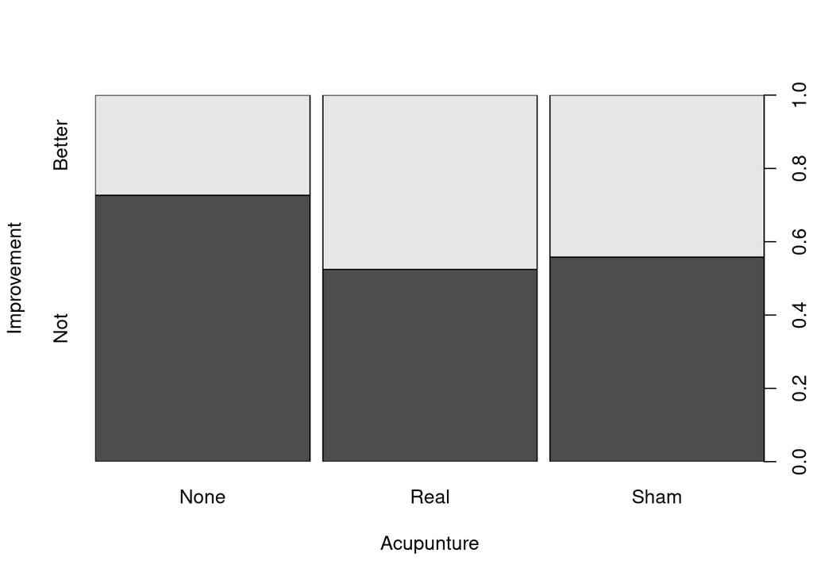

```r
plot(Improvement ~ Acupunture, data = apunc)
```

## Chi-square test (table instead of formulas)

Is there some significant difference among the three groups?

```r
chisq.test(table(apunc))
```

```
##
##  Pearson's Chi-squared test
##
## data:  table(apunc)
## X-squared = 38.054, df = 2, p-value = 5.453e-09
```

## One-way ANOVA

How do different diets affect change in Body Mass Index (BMI)?

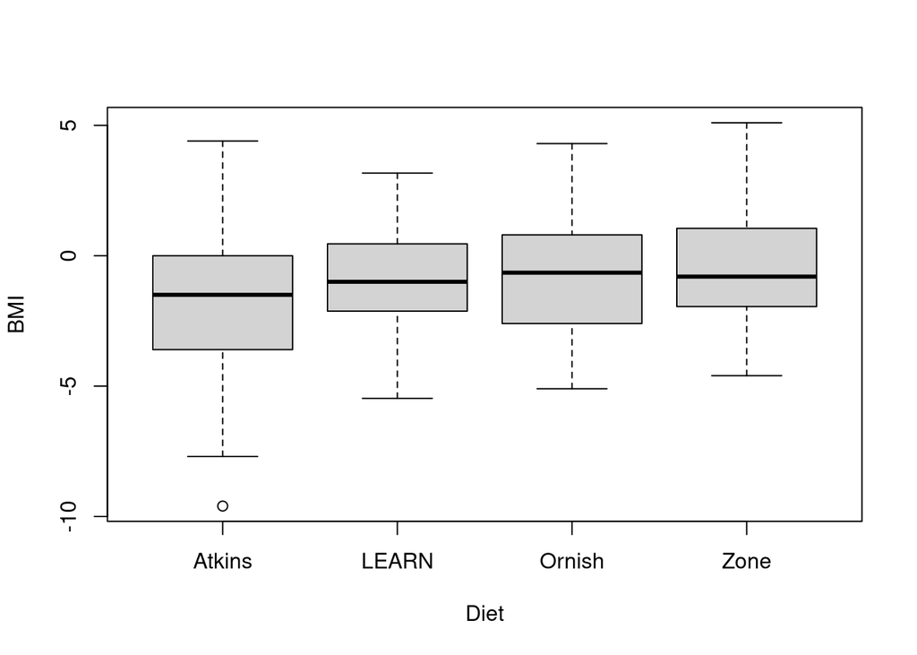

```r
diets <- read.table("http://www.isi-stats.com/isi/data/chap9/Diets.txt",
                    header = TRUE,
                    stringsAsFactors = TRUE)
plot(BMI ~ Diet, data = diets)
```

## One-way ANOVA

Is there an association between the type of diet and the change in BMI?

```r
d.aov <- aov(BMI ~ Diet, data = diets)
anova(d.aov)
```

```
## Analysis of Variance Table
##
## Response: BMI
##            Df  Sum Sq Mean Sq F value  Pr(>F)
## Diet        3   54.17 18.0562  3.8001 0.01063 *
## Residuals 307 1458.71  4.7515
## ---
## Signif. codes:  0 '***' 0.001 '**' 0.01 '*' 0.05 '.' 0.1 ' ' 1
```

## Tukey HSD follow-up

Where does the association lie, i.e., which pairs of groups are significantly different?

```r
TukeyHSD(d.aov)
```

```
##   Tukey multiple comparisons of means
##     95% family-wise confidence level
##
## Fit: aov(formula = BMI ~ Diet, data = diets)
##
## $Diet
##                    diff         lwr      upr     p adj
## LEARN-Atkins  0.7291304 -0.17258536 1.630846 0.1590577
## Ornish-Atkins 0.8809125 -0.02954526 1.791370 0.0619904
## Zone-Atkins   1.1202696  0.21855388 2.021985 0.0079830
## Ornish-LEARN  0.1517821 -0.75293279 1.056497 0.9726913
## Zone-LEARN    0.3911392 -0.50477761 1.287056 0.6726684
## Zone-Ornish   0.2393571 -0.66535784 1.144072 0.9033681
```

## Regression/Correlation

Is there an association between the price of a textbook and the number of pages it has?

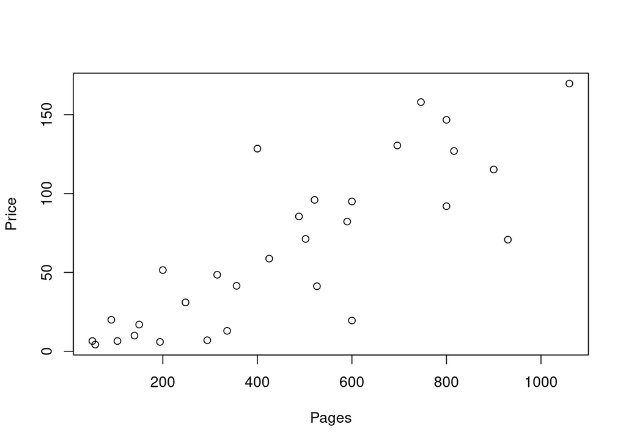

```r
textbooks <- read.table("http://www.isi-stats.com/isi/data/chap10/TextbookPrices.txt", header = TRUE)
plot(Price ~ Pages, data = textbooks)
```

## Regression/Correlation

```r
bookmodel <- lm(Price ~ Pages, data = textbooks)
summary(bookmodel)
```

```
##
## Call:
## lm(formula = Price ~ Pages, data = textbooks)
##
## Residuals:
##     Min      1Q  Median      3Q     Max
## -65.475 -12.324  -0.584  15.304  72.991
##
## Coefficients:
##             Estimate Std. Error t value Pr(>|t|)
## (Intercept) -3.42231   10.46374  -0.327    0.746
## Pages        0.14733    0.01925   7.653 2.45e-08 ***
## ---
## Signif. codes:  0 '***' 0.001 '**' 0.01 '*' 0.05 '.' 0.1 ' ' 1
##
## Residual standard error: 29.76 on 28 degrees of freedom
## Multiple R-squared:  0.6766, Adjusted R-squared:  0.665
## F-statistic: 58.57 on 1 and 28 DF,  p-value: 2.452e-08
```

## Correlation Matrix

```r
cor(textbooks)
```

```
##           Pages     Price
## Pages 1.0000000 0.8225404
## Price 0.8225404 1.0000000
```

## Selecting numeric columns

The first four columns of the `iris` data set were numeric, so if we want a correlation matrix, we have to select just those, and omit the categorical column 5.

```r
cor(iris[,1:4])
```

```
##              Sepal.Length Sepal.Width Petal.Length Petal.Width
## Sepal.Length    1.0000000  -0.1175698    0.8717538   0.8179411
## Sepal.Width    -0.1175698   1.0000000   -0.4284401  -0.3661259
## Petal.Length    0.8717538  -0.4284401    1.0000000   0.9628654
## Petal.Width     0.8179411  -0.3661259    0.9628654   1.0000000
```

## Multiple Regression

```r
cereal <- read.table("http://math.westmont.edu/data/cereal.csv",
                     header=TRUE,
                     stringsAsFactors = TRUE,
                     sep=";")
summary(cereal)
```

```
##                         name    mfr    type      calories      protein
##  100 Percent Bran         : 1   A: 1   C:73   Min.   : 50   Min.   :1.000
##  100 Percent Natural Bran : 1   G:22   H: 1   1st Qu.:100   1st Qu.:2.000
##  All-Bran                 : 1   K:23          Median :110   Median :2.500
##  All-Bran with Extra Fiber: 1   N: 5          Mean   :107   Mean   :2.514
##  Apple Cinnamon Cheerios  : 1   P: 9          3rd Qu.:110   3rd Qu.:3.000
##  Apple Jacks              : 1   Q: 7          Max.   :160   Max.   :6.000
##  (Other)                  :68   R: 7
##       fat        sodium          fiber            carbo           sugars
##  Min.   :0   Min.   :  0.0   Min.   : 0.000   Min.   : 5.00   Min.   : 0.000
##  1st Qu.:0   1st Qu.:135.0   1st Qu.: 0.250   1st Qu.:12.00   1st Qu.: 3.000
##  Median :1   Median :180.0   Median : 2.000   Median :14.50   Median : 7.000
##  Mean   :1   Mean   :162.4   Mean   : 2.176   Mean   :14.73   Mean   : 7.108
##  3rd Qu.:1   3rd Qu.:217.5   3rd Qu.: 3.000   3rd Qu.:17.00   3rd Qu.:11.000
##  Max.   :5   Max.   :320.0   Max.   :14.000   Max.   :23.00   Max.   :15.000
##
##      potass          vitamins          shelf           weight
##  Min.   : 15.00   Min.   :  0.00   Min.   :1.000   Min.   :0.500
##  1st Qu.: 41.25   1st Qu.: 25.00   1st Qu.:1.250   1st Qu.:1.000
##  Median : 90.00   Median : 25.00   Median :2.000   Median :1.000
##  Mean   : 98.51   Mean   : 29.05   Mean   :2.216   Mean   :1.031
##  3rd Qu.:120.00   3rd Qu.: 25.00   3rd Qu.:3.000   3rd Qu.:1.000
##  Max.   :330.00   Max.   :100.00   Max.   :3.000   Max.   :1.500
##
##       cups            rating
##  Min.   :0.2500   Min.   :18.04
##  1st Qu.:0.6700   1st Qu.:32.45
##  Median :0.7500   Median :40.25
##  Mean   :0.8216   Mean   :42.37
##  3rd Qu.:1.0000   3rd Qu.:50.52
##  Max.   :1.5000   Max.   :93.70
##
```

## Multiple explanatory variables

Can we predict what the rating will be, given sugar, fiber, calorie, and protein content?

Notice that the formula lists multiple explanatory variables as addition; this indicates the linear model.

```r
cereal.model <- lm(rating ~ sugars + fiber + calories + protein, data = cereal)
summary(cereal.model)
```

```
##
## Call:
## lm(formula = rating ~ sugars + fiber + calories + protein, data = cereal)
##
## Residuals:
##      Min       1Q   Median       3Q      Max
## -11.7960  -3.1484  -0.5602   2.7014  13.0237
##
## Coefficients:
##             Estimate Std. Error t value Pr(>|t|)
## (Intercept) 68.18926    3.84392  17.740  < 2e-16 ***
## sugars      -1.51063    0.19066  -7.923 2.76e-11 ***
## fiber        2.03753    0.32769   6.218 3.37e-08 ***
## calories    -0.23225    0.04312  -5.386 9.40e-07 ***
## protein      2.12632    0.76016   2.797  0.00667 **
## ---
## Signif. codes:  0 '***' 0.001 '**' 0.01 '*' 0.05 '.' 0.1 ' ' 1
##
## Residual standard error: 5.184 on 69 degrees of freedom
## Multiple R-squared:  0.871,  Adjusted R-squared:  0.8635
## F-statistic: 116.5 on 4 and 69 DF,  p-value: < 2.2e-16
```

## Logistic Regression

Does the social status of a driver predict whether the driver will stop for a pedestrian in a crosswalk?

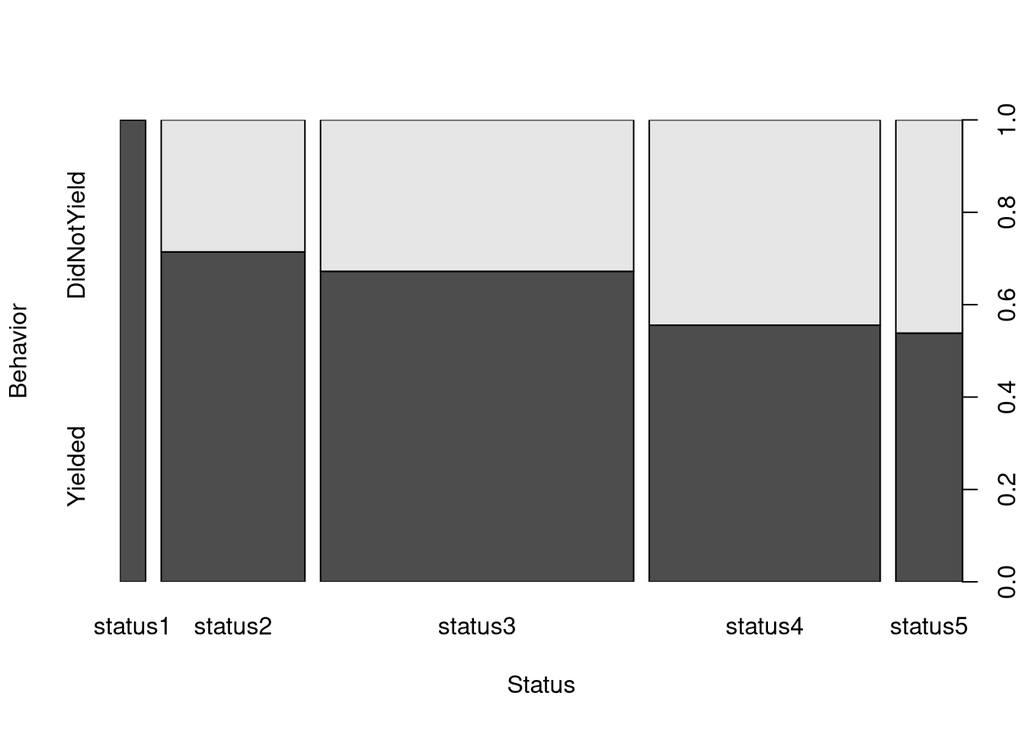

```r
drivers <- read.table("http://math.westmont.edu/ma5/carstatus.txt",
                      header = TRUE,
                      stringsAsFactors = TRUE)
plot(Behavior ~ Status, data = drivers)
```

## Status coded as categorical (factor)

```r
summary(drivers)
```

```
##      Status          Behavior      Speed
##  status1: 5   DidNotYield:54   Min.   :20.00
##  status2:28   Yielded    :98   1st Qu.:31.95
##  status3:61                    Median :35.15
##  status4:45                    Mean   :35.16
##  status5:13                    3rd Qu.:38.48
##                                Max.   :48.30
```

## Change status to numeric (quantitative)

```r
drivers$Status <- as.numeric(drivers$Status)
summary(drivers)
```

```
##      Status             Behavior      Speed
##  Min.   :1.000   DidNotYield:54   Min.   :20.00
##  1st Qu.:3.000   Yielded    :98   1st Qu.:31.95
##  Median :3.000                    Median :35.15
##  Mean   :3.217                    Mean   :35.16
##  3rd Qu.:4.000                    3rd Qu.:38.48
##  Max.   :5.000                    Max.   :48.30
```

## Logistic Regression in R

Can we predict the probability of yielding if we know the social status of the driver?

```r
d.logit <- glm(Behavior ~ Status, data = drivers, family = binomial)
summary(d.logit)
```

```
##
## Call:
## glm(formula = Behavior ~ Status, family = binomial, data = drivers)
##
## Deviance Residuals:
##     Min       1Q   Median       3Q      Max
## -1.6685  -1.3082   0.7561   0.8964   1.2200
##
## Coefficients:
##             Estimate Std. Error z value Pr(>|z|)
## (Intercept)   1.9100     0.6428   2.971  0.00297 **
## Status       -0.4019     0.1866  -2.154  0.03122 *
## ---
## Signif. codes:  0 '***' 0.001 '**' 0.01 '*' 0.05 '.' 0.1 ' ' 1
##
## (Dispersion parameter for binomial family taken to be 1)
##
##     Null deviance: 197.80  on 151  degrees of freedom
## Residual deviance: 192.94  on 150  degrees of freedom
## AIC: 196.94
##
## Number of Fisher Scoring iterations: 4
```

## Logistic prediction curve

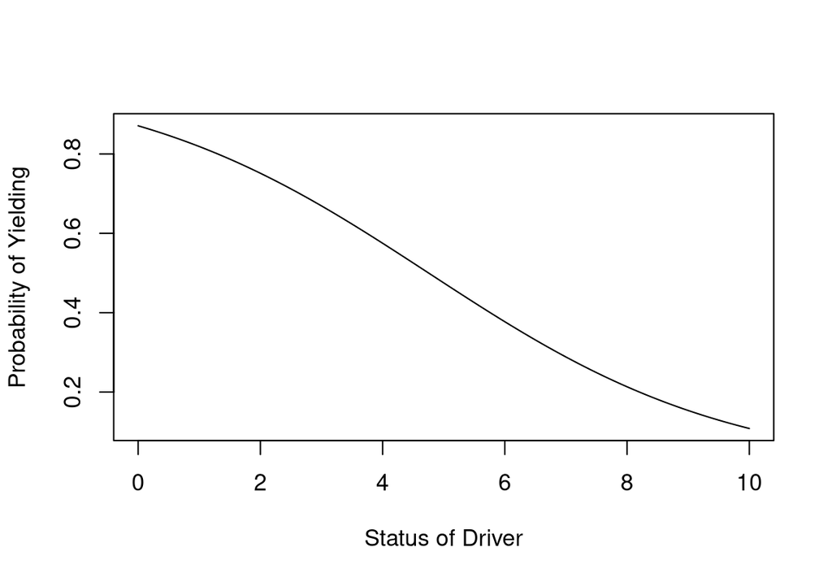

```r
b <- coef(d.logit)
Phat <- function(x) {exp(b[1]+x*b[2])/(1+exp(b[1]+x*b[2]))}
plot(Phat, xlim = c(0,10), xlab="Status of Driver", ylab="Probability of Yielding")
```

## Analysis of Covariance

This example is from https://rcompanion.org.

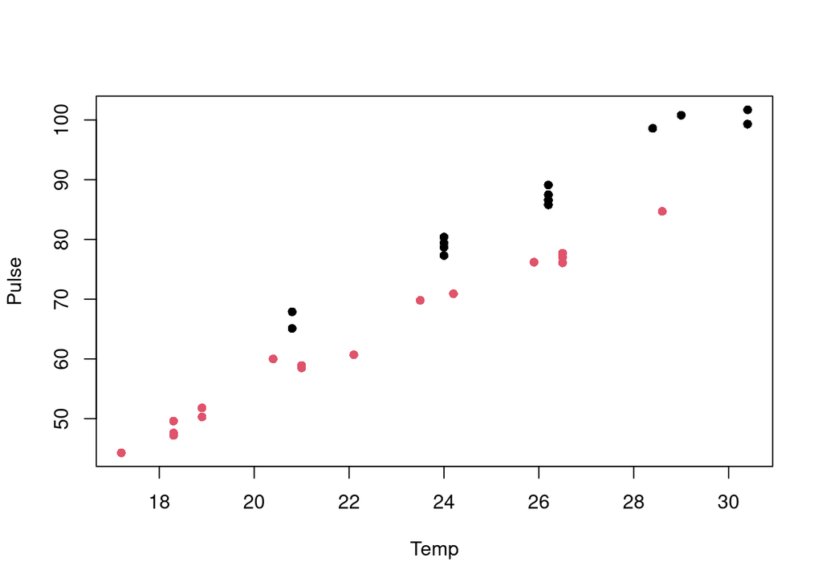

```r
crickets <- read.table("http://math.westmont.edu/data/crickets.txt",
                       header = TRUE,
                       stringsAsFactors = TRUE)
plot(Pulse ~ Temp,
     col = Species,
     data = crickets,
     pch = 16)
```

## ANCOVA

- Response variable: Pulse
- Explanatory variables: Temp (quantitative) and Species (categorical)

If we want to see interaction effects, we use * instead of + in the formula.

```r
cricket.model1 <- lm(Pulse ~ Temp * Species, data = crickets)
summary(cricket.model1)
```

```
##
## Call:
## lm(formula = Pulse ~ Temp * Species, data = crickets)
##
## Residuals:
##     Min      1Q  Median      3Q     Max
## -3.7031 -1.3417 -0.1235  0.8100  3.6330
##
## Coefficients:
##                 Estimate Std. Error t value Pr(>|t|)
## (Intercept)     -11.0408     4.1515  -2.659    0.013 *
## Temp              3.7514     0.1601  23.429   <2e-16 ***
## Speciesniv       -4.3484     4.9617  -0.876    0.389
## Temp:Speciesniv  -0.2340     0.2009  -1.165    0.254
## ---
## Signif. codes:  0 '***' 0.001 '**' 0.01 '*' 0.05 '.' 0.1 ' ' 1
##
## Residual standard error: 1.775 on 27 degrees of freedom
## Multiple R-squared:  0.9901, Adjusted R-squared:  0.989
## F-statistic: 898.9 on 3 and 27 DF,  p-value: < 2.2e-16
```

It looks like interaction is not significant, so the slopes for the two species are not significantly different.

## Type II test instead

If you want to do Type II sums of squares instead, you can use the `car` package, which you may need to install. Do this in the lower right pane of RStudio.

```r
library(car)
Anova(cricket.model1, type = "II")
```

```
## Anova Table (Type II tests)
##
## Response: Pulse
##              Sum Sq Df  F value    Pr(>F)
## Temp         4376.1  1 1388.839 < 2.2e-16 ***
## Species       598.0  1  189.789 9.907e-14 ***
## Temp:Species    4.3  1    1.357    0.2542
## Residuals      85.1 27
## ---
## Signif. codes:  0 '***' 0.001 '**' 0.01 '*' 0.05 '.' 0.1 ' ' 1
```

## Model without interactions

Since the interactions were not significant, we can model without interactions.

```r
cricket.model2 <- lm(Pulse ~ Temp + Species, data = crickets)
Anova(cricket.model2)
```

```
## Anova Table (Type II tests)
##
## Response: Pulse
##           Sum Sq Df F value    Pr(>F)
## Temp      4376.1  1  1371.4 < 2.2e-16 ***
## Species    598.0  1   187.4 6.272e-14 ***
## Residuals   89.3 28
## ---
## Signif. codes:  0 '***' 0.001 '**' 0.01 '*' 0.05 '.' 0.1 ' ' 1
```

`Species` is significant, so the intercepts are different.

```r
summary(cricket.model2)
```

```
##
## Call:
## lm(formula = Pulse ~ Temp + Species, data = crickets)
##
## Residuals:
##     Min      1Q  Median      3Q     Max
## -3.0128 -1.1296 -0.3912  0.9650  3.7800
##
## Coefficients:
##              Estimate Std. Error t value Pr(>|t|)
## (Intercept)  -7.21091    2.55094  -2.827  0.00858 **
## Temp          3.60275    0.09729  37.032  < 2e-16 ***
## Speciesniv  -10.06529    0.73526 -13.689 6.27e-14 ***
## ---
## Signif. codes:  0 '***' 0.001 '**' 0.01 '*' 0.05 '.' 0.1 ' ' 1
##
## Residual standard error: 1.786 on 28 degrees of freedom
## Multiple R-squared:  0.9896, Adjusted R-squared:  0.9888
## F-statistic:  1331 on 2 and 28 DF,  p-value: < 2.2e-16
```

# References

## UCLA Test Chooser

A summary of explanatory/response scenarios, with examples in R (and other languages).

https://stats.idre.ucla.edu/other/mult-pkg/whatstat/

## R Companion

*An R Companion for the Handbook of Biological Statistics*, by Salvatore S. Mangiafico:

https://rcompanion.org/rcompanion/

## These notes

Remember that you can make an HTML version of this document by clicking on the “Knit” icon at the top of the Source pane. You can also knit to other formats.